# NBA Shot Log Analyzer - An R Shiny App

Sai S Sampathkumar (github: ssaisushanth45)  
20 July 2017

App address: https://ssaisushanth45.shinyapps.io/NBA_Shot_Log_Analyzer/

[figure not shown]

### NBA Shot Log Analyzer - Data

My choice of dataset & application was based on four things:

- Simple to understand
- Fun to play with
- An opportunity to learn something new
- Useful in building my portfolio for my start-up (Spanstatz)

Research on publicly available data sets led me to Dan Becker's Kaggle posting: https://www.kaggle.com/dansbecker/nba-shot-logs

I wanted to create an interactive R Shiny app based on this data to learn and play with something I am passionate about.

As a next step, I hope to add shot chart visualization to this app and may be stretch across to handle different sports (FIFA, NHL, Cricket etc.).

### NBA Shot Log Analyzer - App - View

The app lets the user choose the player he/she may want to pick to understand better based on NBA season 2014-15

[figure not shown]

### NBA Shot Log Analyzer - Charts - Closer View

- As a LeBron James fan who has seen him play for St.Vincents at the Gund (now, Quicken) Arena, I had to start by looking at his numbers.
- App is set for 4 charts: Home vs. Away, Win vs. Loss, By Distance (as Table - just for kicks) and By defender. Embedded code shows only 2 here.

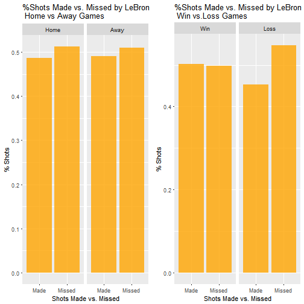

### Contact Us

We would love to hear from you. Email us:

*sss@spanstatz.com*

**Acknowledgements:**

Dan B, Ed Maia, Todd Schneider, Andy Lyons, Augustin Luna, Coursera.

Thank you!!